# HandsOn 02

```r
library(dlookr)
library(kableExtra)
env <- new.env()
with(env, library(dlookr))
```

```r
## install.packages("knitr")
## install.packages("tidytext")
library(ggplot2)
library(vegan)
library(conflicted)
library(dplyr)
library(tidyverse)
## with(env, knitr::knit("Hands_On 02.Rmd", "Hands_On 02.pdf"))
```

# CALIDAD DE DATOS Y PRE-PROCESAMIENTO

## 1.- Evaluación de la Calidad de los Datos

### Cargar los siguientes paquetes dplyr, na.tools, tidyimpute (versión de github decisionpatterns/tidyimpute”) Cargar el data set carInsurance que trata de las puntuaciones de riesgo de seguro de los carros basado en varias caracteristicas de cada carro

#### a) Revisar si hay algún valor no agregado

```r
load("C:/Users/Edgar/Documents/GitHub/DataMining_and_MachineLearning_EdgarV/data/HandsOn_Data/carInsurance.Rdata")
## ls()
df <- carIns
##df
any(is.na(df))
```

```
[1] TRUE
```

```r
## si hay valores NA
```

### b) Contar el numero de casos que tienen almenos un valor no agregado

```r
## ls()
df <- carIns
##df
df1 <- df %>%
    dplyr::filter(any(is.na(df)))%>%
    count()
## el numero de NA´s es:
df1
```

| n |
| --- |
| 205 |

| n <int> |  |  |  |  |
| --- | --- | --- | --- | --- |
| 205 |  |  |  |  |

1 row

### c) crear un nuevo data set a partir de la remoción de todos los casos que tienen valores no agregados

```r
load("C:/Users/Edgar/Documents/GitHub/DataMining_and_MachineLearning_EdgarV/data/HandsOn_Data/carInsurance.Rdata")
## ls()
df <- carIns
new_dataset <- df %>%
    drop_na()
## de esta forma se eliminan las filas que contienen NA
head(new_dataset)
```

| symb | normLoss | make | fuelType | aspiration | nDoors | bodyStyle | driveWheels | engineLocation | wheelBase | length | width | height | curbWeight | engineType | nrCylinds | engineSize | fuelSystem | bore | stroke | compressionRatio | horsePower | peakRpm | cityMpg | highwayMpg | price |
| --- | --- | --- | --- | --- | --- | --- | --- | --- | --- | --- | --- | --- | --- | --- | --- | --- | --- | --- | --- | --- | --- | --- | --- | --- | --- |
| 2 | 164 | audi | gas | std | four | sedan | fwd | front | 99.8 | 176.6 | 66.2 | 54.3 | 2337 | ohc | four | 109 | mpfi | 3.19 | 3.4 | 10.0 | 102 | 5500 | 24 | 30 | 13950 |
| 2 | 164 | audi | gas | std | four | sedan | 4wd | front | 99.4 | 176.6 | 66.4 | 54.3 | 2824 | ohc | five | 136 | mpfi | 3.19 | 3.4 | 8.0 | 115 | 5500 | 18 | 22 | 17450 |
| 1 | 158 | audi | gas | std | four | sedan | fwd | front | 105.8 | 192.7 | 71.4 | 55.7 | 2844 | ohc | five | 136 | mpfi | 3.19 | 3.4 | 8.5 | 110 | 5500 | 19 | 25 | 17710 |
| 1 | 158 | audi | gas | turbo | four | sedan | fwd | front | 105.8 | 192.7 | 71.4 | 55.9 | 3086 | ohc | five | 131 | mpfi | 3.13 | 3.4 | 8.3 | 140 | 5500 | 17 | 20 | 23875 |
| 2 | 192 | bmw | gas | std | two | sedan | rwd | front | 101.2 | 176.8 | 64.8 | 54.3 | 2395 | ohc | four | 108 | mpfi | 3.50 | 2.8 | 8.8 | 101 | 5800 | 23 | 29 | 16430 |
| 0 | 192 | bmw | gas | std | four | sedan | rwd | front | 101.2 | 176.8 | 64.8 | 54.3 | 2395 | ohc | four | 108 | mpfi | 3.50 | 2.8 | 8.8 | 101 | 5800 | 23 | 29 | 16925 |

| symb <int> | normLoss <int> | make <fctr> | fuelType <fctr> | aspiration <fctr> | nDoors <fctr> | bodyStyle <fctr> | driveWheels <fctr> | engineLocation <fctr> | wheelBase <dbl> |  |
| --- | --- | --- | --- | --- | --- | --- | --- | --- | --- | --- |
| 2 | 164 | audi | gas | std | four | sedan | fwd | front | 99.8 |  |
| 2 | 164 | audi | gas | std | four | sedan | 4wd | front | 99.4 |  |
| 1 | 158 | audi | gas | std | four | sedan | fwd | front | 105.8 |  |
| 1 | 158 | audi | gas | turbo | four | sedan | fwd | front | 105.8 |  |
| 2 | 192 | bmw | gas | std | two | sedan | rwd | front | 101.2 |  |
| 0 | 192 | bmw | gas | std | four | sedan | rwd | front | 101.2 |  |

6 rows | 1-10 of 26 columns

### d) crear un nuevo dataset a partir del reemplazo de todos los valores no agregados por 0

```r
load("C:/Users/Edgar/Documents/GitHub/DataMining_and_MachineLearning_EdgarV/data/HandsOn_Data/carInsurance.Rdata")
## ls()
df <- carIns
new_dataset <- df %>%
    mutate_all(~ifelse(is.na(.), 0, .))
## observamos que se reemplaza todos los NA por 0 y en el caso que haya un NA en categorias, le cambia a int y la categoria  se transforma en numero
head(new_dataset)
```

| symb | normLoss | make | fuelType | aspiration | nDoors | bodyStyle | driveWheels | engineLocation | wheelBase | length | width | height | curbWeight | engineType | nrCylinds | engineSize | fuelSystem | bore | stroke | compressionRatio | horsePower | peakRpm | cityMpg | highwayMpg | price |
| --- | --- | --- | --- | --- | --- | --- | --- | --- | --- | --- | --- | --- | --- | --- | --- | --- | --- | --- | --- | --- | --- | --- | --- | --- | --- |
| 3 | 0 | 1 | 2 | 1 | 2 | 1 | 3 | 1 | 88.6 | 168.8 | 64.1 | 48.8 | 2548 | 1 | 3 | 130 | 6 | 3.47 | 2.68 | 9.0 | 111 | 5000 | 21 | 27 | 13495 |
| 3 | 0 | 1 | 2 | 1 | 2 | 1 | 3 | 1 | 88.6 | 168.8 | 64.1 | 48.8 | 2548 | 1 | 3 | 130 | 6 | 3.47 | 2.68 | 9.0 | 111 | 5000 | 21 | 27 | 16500 |
| 1 | 0 | 1 | 2 | 1 | 2 | 3 | 3 | 1 | 94.5 | 171.2 | 65.5 | 52.4 | 2823 | 6 | 4 | 152 | 6 | 2.68 | 3.47 | 9.0 | 154 | 5000 | 19 | 26 | 16500 |
| 2 | 164 | 2 | 2 | 1 | 1 | 4 | 2 | 1 | 99.8 | 176.6 | 66.2 | 54.3 | 2337 | 4 | 3 | 109 | 6 | 3.19 | 3.40 | 10.0 | 102 | 5500 | 24 | 30 | 13950 |
| 2 | 164 | 2 | 2 | 1 | 1 | 4 | 1 | 1 | 99.4 | 176.6 | 66.4 | 54.3 | 2824 | 4 | 2 | 136 | 6 | 3.19 | 3.40 | 8.0 | 115 | 5500 | 18 | 22 | 17450 |
| 2 | 0 | 2 | 2 | 1 | 2 | 4 | 2 | 1 | 99.8 | 177.3 | 66.3 | 53.1 | 2507 | 4 | 2 | 136 | 6 | 3.19 | 3.40 | 8.5 | 110 | 5500 | 19 | 25 | 15250 |

| symb <int> | normLoss <dbl> | make <int> | fuelType <int> | aspiration <int> | nDoors <dbl> | bodyStyle <int> | driveWheels <int> | engineLocation <int> | wheelBase <dbl> |  |
| --- | --- | --- | --- | --- | --- | --- | --- | --- | --- | --- |
| 3 | 0 | 1 | 2 | 1 | 2 | 1 | 3 | 1 | 88.6 |  |
| 3 | 0 | 1 | 2 | 1 | 2 | 1 | 3 | 1 | 88.6 |  |
| 1 | 0 | 1 | 2 | 1 | 2 | 3 | 3 | 1 | 94.5 |  |
| 2 | 164 | 2 | 2 | 1 | 1 | 4 | 2 | 1 | 99.8 |  |
| 2 | 164 | 2 | 2 | 1 | 1 | 4 | 1 | 1 | 99.4 |  |
| 2 | 0 | 2 | 2 | 1 | 2 | 4 | 2 | 1 | 99.8 |  |

6 rows | 1-10 of 26 columns

### e) Crear un nuevo dataset a partir del ingreso del promedio en todas las columnas las cuales tienen sus datos de tipo double

```r
load("C:/Users/Edgar/Documents/GitHub/DataMining_and_MachineLearning_EdgarV/data/HandsOn_Data/carInsurance.Rdata")
## ls()
df <- carIns
new_dataset <- df %>%
    mutate_all(~ifelse(is.na(.), 0, .))

media_doubles <- new_dataset %>%
                  select_if(is.double) %>%
                  summarize(across(everything(), mean))

media_doubles
```

| normLoss | nDoors | wheelBase | length | width | height | bore | stroke | compressionRatio | horsePower | peakRpm | price |
| --- | --- | --- | --- | --- | --- | --- | --- | --- | --- | --- | --- |
| 97.6 | 1.42439 | 98.75659 | 174.0493 | 65.9078 | 53.72488 | 3.26478 | 3.191902 | 10.14254 | 103.239 | 5075.366 | 12949.43 |

| normLoss <dbl> | nDoors <dbl> | wheelBase <dbl> | length <dbl> | width <dbl> | height <dbl> | bore <dbl> | stroke <dbl> | compressionRatio <dbl> | horsePower <dbl> |  |
| --- | --- | --- | --- | --- | --- | --- | --- | --- | --- | --- |
| 97.6 | 1.42439 | 98.75659 | 174.0493 | 65.9078 | 53.72488 | 3.26478 | 3.191902 | 10.14254 | 103.239 |  |

1 row | 1-10 of 12 columns

```r
NA
```

### f) Crear un nuevo dataset a partir del ingreso de la moda en todas las columnas con valores de tipo Integer

```r
load("C:/Users/Edgar/Documents/GitHub/DataMining_and_MachineLearning_EdgarV/data/HandsOn_Data/carInsurance.Rdata")
## ls()
df <- carIns
new_dataset <- df %>%
    mutate_all(~ifelse(is.na(.), 0, .))
############################FUNCION MODA##############################
Moda <- function(x) {
  ux <- unique(x)
  ux[which.max(tabulate(match(x, ux)))]
}
######################################################################
moda_integer <- new_dataset %>%
                  select_if(is.integer) %>%
                  summarize(across(everything(), Moda))

moda_integer
```

| symb | make | fuelType | aspiration | bodyStyle | driveWheels | engineLocation | curbWeight | engineType | nrCylinds | engineSize | fuelSystem | cityMpg | highwayMpg |
| --- | --- | --- | --- | --- | --- | --- | --- | --- | --- | --- | --- | --- | --- |
| 0 | 20 | 2 | 1 | 4 | 2 | 1 | 2385 | 4 | 3 | 122 | 6 | 31 | 25 |

| symb <int> | make <int> | fuelType <int> | aspiration <int> | bodyStyle <int> | driveWheels <int> | engineLocation <int> | curbWeight <int> | engineType <int> |  |
| --- | --- | --- | --- | --- | --- | --- | --- | --- | --- |
| 0 | 20 | 2 | 1 | 4 | 2 | 1 | 2385 | 4 |  |

1 row | 1-9 of 14 columns

```r
NA
```

### f) Crear un nuevo data set a partir del ingreso de valores mas frecuentes para la columna “inDoors”.

```r
load("C:/Users/Edgar/Documents/GitHub/DataMining_and_MachineLearning_EdgarV/data/HandsOn_Data/carInsurance.Rdata")
## ls()
df <- carIns
new_dataset <- df %>%
    mutate_all(~ifelse(is.na(.), 0, .))

tabla_nDoors <- new_dataset %>%
                select(nDoors)
tabla_nDoors
```

| nDoors |
| --- |
| 2 |
| 2 |
| 2 |
| 1 |
| 1 |
| 2 |
| 1 |
| 1 |
| 1 |
| 2 |

[output cut: 195 more lines]

| nDoors <dbl> |  |  |  |  |
| --- | --- | --- | --- | --- |
| 2 |  |  |  |  |
| 2 |  |  |  |  |
| 2 |  |  |  |  |
| 1 |  |  |  |  |
| 1 |  |  |  |  |
| 2 |  |  |  |  |
| 1 |  |  |  |  |
| 1 |  |  |  |  |
| 1 |  |  |  |  |
| 2 |  |  |  |  |

...

21

1-10 of 205 rows

```r
tabla_mas_frecuente <- table(tabla_nDoors)

valor_mas_frecuente <- names(tabla_mas_frecuente)[tabla_mas_frecuente == max(tabla_mas_frecuente)]

## muestra el valor mas frecuente entre 0, 1, 2
valor_mas_frecuente
```

```
[1] "1"
```

### g) Combinar los tres últimas imputaciones para obtener un dataset final, ¿hay algunos casos duplicados?

```r
load("C:/Users/Edgar/Documents/GitHub/DataMining_and_MachineLearning_EdgarV/data/HandsOn_Data/carInsurance.Rdata")
## ls()
df <- carIns
new_dataset <- df %>%
    mutate_all(~ifelse(is.na(.), 0, .))

media_doubles <- new_dataset %>%
                  select_if(is.double) %>%
                  summarize(across(everything(), mean))
##########DATASET 1###############
media_doubles
```

| normLoss | nDoors | wheelBase | length | width | height | bore | stroke | compressionRatio | horsePower | peakRpm | price |
| --- | --- | --- | --- | --- | --- | --- | --- | --- | --- | --- | --- |
| 97.6 | 1.42439 | 98.75659 | 174.0493 | 65.9078 | 53.72488 | 3.26478 | 3.191902 | 10.14254 | 103.239 | 5075.366 | 12949.43 |

| normLoss <dbl> | nDoors <dbl> | wheelBase <dbl> | length <dbl> | width <dbl> | height <dbl> | bore <dbl> | stroke <dbl> | compressionRatio <dbl> | horsePower <dbl> |  |
| --- | --- | --- | --- | --- | --- | --- | --- | --- | --- | --- |
| 97.6 | 1.42439 | 98.75659 | 174.0493 | 65.9078 | 53.72488 | 3.26478 | 3.191902 | 10.14254 | 103.239 |  |

1 row | 1-10 of 12 columns

```r
##################################

############################FUNCION MODA##############################
Moda <- function(x) {
  ux <- unique(x)
  ux[which.max(tabulate(match(x, ux)))]
}
######################################################################
moda_integer <- new_dataset %>%
                  select_if(is.integer) %>%
                  summarize(across(everything(), Moda))
###########DATASET 2###############
moda_integer
```

| symb | make | fuelType | aspiration | bodyStyle | driveWheels | engineLocation | curbWeight | engineType | nrCylinds | engineSize | fuelSystem | cityMpg | highwayMpg |
| --- | --- | --- | --- | --- | --- | --- | --- | --- | --- | --- | --- | --- | --- |
| 0 | 20 | 2 | 1 | 4 | 2 | 1 | 2385 | 4 | 3 | 122 | 6 | 31 | 25 |

| symb <int> | make <int> | fuelType <int> | aspiration <int> | bodyStyle <int> | driveWheels <int> | engineLocation <int> | curbWeight <int> | engineType <int> |  |
| --- | --- | --- | --- | --- | --- | --- | --- | --- | --- |
| 0 | 20 | 2 | 1 | 4 | 2 | 1 | 2385 | 4 |  |

1 row | 1-9 of 14 columns

```r
##################################

tabla_nDoors <- new_dataset %>%
                select(nDoors)
tabla_nDoors
```

| nDoors |
| --- |
| 2 |
| 2 |
| 2 |
| 1 |
| 1 |
| 2 |
| 1 |
| 1 |
| 1 |
| 2 |

[output cut: 195 more lines]

| nDoors <dbl> |  |  |  |  |
| --- | --- | --- | --- | --- |
| 2 |  |  |  |  |
| 2 |  |  |  |  |
| 2 |  |  |  |  |
| 1 |  |  |  |  |
| 1 |  |  |  |  |
| 2 |  |  |  |  |
| 1 |  |  |  |  |
| 1 |  |  |  |  |
| 1 |  |  |  |  |
| 2 |  |  |  |  |

...

21

1-10 of 205 rows

```r
tabla_mas_frecuente <- table(tabla_nDoors)

valor_mas_frecuente <- names(tabla_mas_frecuente)[tabla_mas_frecuente == max(tabla_mas_frecuente)]

## muestra el valor mas frecuente entre 0, 1, 2
###########DATASET 3###############
valor_mas_frecuente
```

```
[1] "1"
```

```r
###################################

df_final <- merge(media_doubles,moda_integer)

df_final
```

| normLoss | nDoors | wheelBase | length | width | height | bore | stroke | compressionRatio | horsePower | peakRpm | price | symb | make | fuelType | aspiration | bodyStyle | driveWheels | engineLocation | curbWeight | engineType | nrCylinds | engineSize | fuelSystem | cityMpg | highwayMpg |
| --- | --- | --- | --- | --- | --- | --- | --- | --- | --- | --- | --- | --- | --- | --- | --- | --- | --- | --- | --- | --- | --- | --- | --- | --- | --- |
| 97.6 | 1.42439 | 98.75659 | 174.0493 | 65.9078 | 53.72488 | 3.26478 | 3.191902 | 10.14254 | 103.239 | 5075.366 | 12949.43 | 0 | 20 | 2 | 1 | 4 | 2 | 1 | 2385 | 4 | 3 | 122 | 6 | 31 | 25 |

| normLoss <dbl> | nDoors <dbl> | wheelBase <dbl> | length <dbl> | width <dbl> | height <dbl> | bore <dbl> | stroke <dbl> | compressionRatio <dbl> | horsePower <dbl> |  |
| --- | --- | --- | --- | --- | --- | --- | --- | --- | --- | --- |
| 97.6 | 1.42439 | 98.75659 | 174.0493 | 65.9078 | 53.72488 | 3.26478 | 3.191902 | 10.14254 | 103.239 |  |

1 row | 1-10 of 26 columns

```r
dup <- any(duplicated(df_final))
## no se encontró valores duplicados
dup
```

```
[1] FALSE
```

# 2.- Pre procesamiento de datos

## 2. Cargar el paquete dlookr, utilizar el mismo dataset carInsurance y aplicar las siguientes transformacionespara el atrbuto precio. ser critico con los resultados obtenidos.

### (a) Apply range-based normalization and z-score normalization.

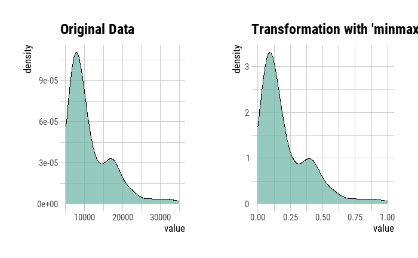

```r
load("C:/Users/Edgar/Documents/GitHub/DataMining_and_MachineLearning_EdgarV/data/HandsOn_Data/carInsurance.Rdata")
df_1 <- carIns
new_dataset1 <- df_1 %>%
    drop_na()
df_rango_base_n <-transform(new_dataset1$price, method = "minmax")
plot(df_rango_base_n)
```

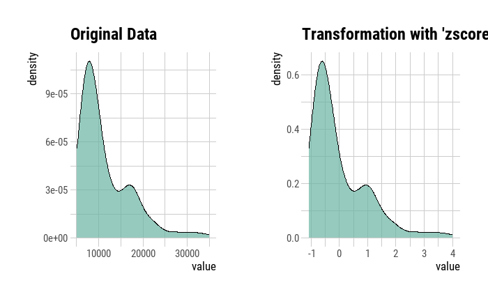

```r
df_zscore <- transform(new_dataset1$price, method = "zscore")
plot(df_zscore)
```

```r
## el resultado no varia las gráficas
```

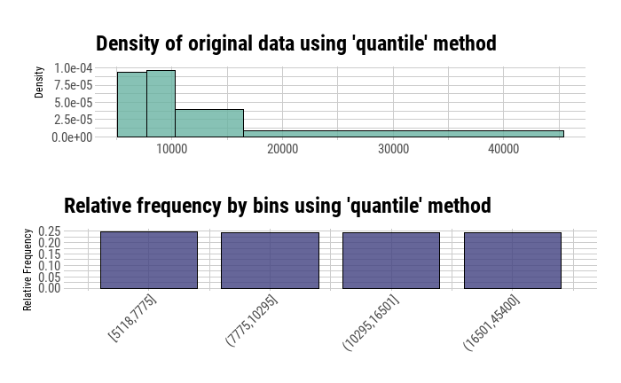

```r
load("C:/Users/Edgar/Documents/GitHub/DataMining_and_MachineLearning_EdgarV/data/HandsOn_Data/carInsurance.Rdata")
## ls()
df_2 <- carIns
discretizacion <- binning(df_2$price, nbins = 4)
##summary(discretizacion)
plot(discretizacion)
```

```r
load("C:/Users/Edgar/Documents/GitHub/DataMining_and_MachineLearning_EdgarV/data/HandsOn_Data/carInsurance.Rdata")
## ls()
df_3 <- carIns

sampled_df <- df_3 %>% sample_frac(0.6)
sampled_df
```

| symb | normLoss | make | fuelType | aspiration | nDoors | bodyStyle | driveWheels | engineLocation | wheelBase | length | width | height | curbWeight | engineType | nrCylinds | engineSize | fuelSystem | bore | stroke | compressionRatio | horsePower | peakRpm | cityMpg | highwayMpg | price |
| --- | --- | --- | --- | --- | --- | --- | --- | --- | --- | --- | --- | --- | --- | --- | --- | --- | --- | --- | --- | --- | --- | --- | --- | --- | --- |
| 2 | 137 | honda | gas | std | two | hatchback | fwd | front | 86.6 | 144.6 | 63.9 | 50.8 | 1819 | ohc | four | 92 | 1bbl | 2.91 | 3.41 | 9.20 | 76 | 6000 | 31 | 38 | 6855 |
| 2 | 168 | nissan | gas | std | two | hardtop | fwd | front | 95.1 | 162.4 | 63.8 | 53.3 | 2008 | ohc | four | 97 | 2bbl | 3.15 | 3.29 | 9.40 | 69 | 5200 | 31 | 37 | 8249 |
| 1 | 101 | honda | gas | std | two | hatchback | fwd | front | 93.7 | 150.0 | 64.0 | 52.6 | 1837 | ohc | four | 79 | 1bbl | 2.91 | 3.07 | 10.10 | 60 | 5500 | 38 | 42 | 5399 |
| -1 | 65 | toyota | gas | std | four | hatchback | fwd | front | 102.4 | 175.6 | 66.5 | 53.9 | 2414 | ohc | four | 122 | mpfi | 3.31 | 3.54 | 8.70 | 92 | 4200 | 27 | 32 | 9988 |
| -2 | 103 | volvo | gas | std | four | sedan | rwd | front | 104.3 | 188.8 | 67.2 | 56.2 | 2935 | ohc | four | 141 | mpfi | 3.78 | 3.15 | 9.50 | 114 | 5400 | 24 | 28 | 15985 |
| 0 | 85 | honda | gas | std | four | sedan | fwd | front | 96.5 | 175.4 | 65.2 | 54.1 | 2465 | ohc | four | 110 | mpfi | 3.15 | 3.58 | 9.00 | 101 | 5800 | 24 | 28 | 12945 |
| 2 | 83 | subaru | gas | std | two | hatchback | 4wd | front | 93.3 | 157.3 | 63.8 | 55.7 | 2240 | ohcf | four | 108 | 2bbl | 3.62 | 2.64 | 8.70 | 73 | 4400 | 26 | 31 | 7603 |
| 0 | 89 | subaru | gas | std | four | wagon | fwd | front | 97.0 | 173.5 | 65.4 | 53.0 | 2290 | ohcf | four | 108 | 2bbl | 3.62 | 2.64 | 9.00 | 82 | 4800 | 28 | 32 | 7463 |
| 0 | 128 | nissan | gas | std | four | sedan | fwd | front | 100.4 | 181.7 | 66.5 | 55.1 | 3095 | ohcv | six | 181 | mpfi | 3.43 | 3.27 | 9.00 | 152 | 5200 | 17 | 22 | 13499 |
| 1 | 103 | nissan | gas | std | four | wagon | fwd | front | 94.5 | 170.2 | 63.8 | 53.5 | 2024 | ohc | four | 97 | 2bbl | 3.15 | 3.29 | 9.40 | 69 | 5200 | 31 | 37 | 7349 |

[output cut: 113 more lines]

| symb <int> | normLoss <int> | make <fctr> | fuelType <fctr> | aspiration <fctr> | nDoors <fctr> | bodyStyle <fctr> | driveWheels <fctr> | engineLocation <fctr> |  |
| --- | --- | --- | --- | --- | --- | --- | --- | --- | --- |
| 2 | 137 | honda | gas | std | two | hatchback | fwd | front |  |
| 2 | 168 | nissan | gas | std | two | hardtop | fwd | front |  |
| 1 | 101 | honda | gas | std | two | hatchback | fwd | front |  |
| -1 | 65 | toyota | gas | std | four | hatchback | fwd | front |  |
| -2 | 103 | volvo | gas | std | four | sedan | rwd | front |  |
| 0 | 85 | honda | gas | std | four | sedan | fwd | front |  |
| 2 | 83 | subaru | gas | std | two | hatchback | 4wd | front |  |
| 0 | 89 | subaru | gas | std | four | wagon | fwd | front |  |
| 0 | 128 | nissan | gas | std | four | sedan | fwd | front |  |
| 1 | 103 | nissan | gas | std | four | wagon | fwd | front |  |

...

13

1-10 of 123 rows | 1-9 of 26 columns

```r
## de las 205 filas me ha tomado una muestra solo del 60% que serian 123 filas
```

#### un muestreo estratificado del 60% de los casos de carros.de acuerdo al atributo tipo de combustible (fuelType)

```r
load("C:/Users/Edgar/Documents/GitHub/DataMining_and_MachineLearning_EdgarV/data/HandsOn_Data/carInsurance.Rdata")
## ls()
df_4 <- carIns

stratified_sample <- df_4 %>%
  group_by(fuelType) %>%
  sample_frac(0.6)
##ahora observamos que nos trae el 60% de la muestra pero agrupado por tipo de combustible
stratified_sample
```

| symb | normLoss | make | fuelType | aspiration | nDoors | bodyStyle | driveWheels | engineLocation | wheelBase | length | width | height | curbWeight | engineType | nrCylinds | engineSize | fuelSystem | bore | stroke | compressionRatio | horsePower | peakRpm | cityMpg | highwayMpg | price |
| --- | --- | --- | --- | --- | --- | --- | --- | --- | --- | --- | --- | --- | --- | --- | --- | --- | --- | --- | --- | --- | --- | --- | --- | --- | --- |
| -1 | 93 | mercedes-benz | diesel | turbo | four | wagon | rwd | front | 110.0 | 190.9 | 70.3 | 58.7 | 3750 | ohc | five | 183 | idi | 3.58 | 3.64 | 21.50 | 123 | 4350 | 22 | 25 | 28248 |
| -1 | 95 | volvo | diesel | turbo | four | sedan | rwd | front | 109.1 | 188.8 | 68.9 | 55.5 | 3217 | ohc | six | 145 | idi | 3.01 | 3.40 | 23.00 | 106 | 4800 | 26 | 27 | 22470 |
| 0 | 161 | peugot | diesel | turbo | four | sedan | rwd | front | 107.9 | 186.7 | 68.4 | 56.7 | 3252 | l | four | 152 | idi | 3.70 | 3.52 | 21.00 | 95 | 4150 | 28 | 33 | 17950 |
| 0 | 93 | mercedes-benz | diesel | turbo | two | hardtop | rwd | front | 106.7 | 187.5 | 70.3 | 54.9 | 3495 | ohc | five | 183 | idi | 3.58 | 3.64 | 21.50 | 123 | 4350 | 22 | 25 | 28176 |
| 0 | 161 | peugot | diesel | turbo | four | sedan | rwd | front | 107.9 | 186.7 | 68.4 | 56.7 | 3252 | l | four | 152 | idi | 3.70 | 3.52 | 21.00 | 95 | 4150 | 28 | 33 | 16900 |
| 0 | 91 | toyota | diesel | std | four | sedan | fwd | front | 95.7 | 166.3 | 64.4 | 53.0 | 2275 | ohc | four | 110 | idi | 3.27 | 3.35 | 22.50 | 56 | 4500 | 34 | 36 | 7898 |
| -1 | 93 | mercedes-benz | diesel | turbo | four | sedan | rwd | front | 115.6 | 202.6 | 71.7 | 56.3 | 3770 | ohc | five | 183 | idi | 3.58 | 3.64 | 21.50 | 123 | 4350 | 22 | 25 | 31600 |
| 0 | 161 | peugot | diesel | turbo | four | sedan | rwd | front | 107.9 | 186.7 | 68.4 | 56.7 | 3197 | l | four | 152 | idi | 3.70 | 3.52 | 21.00 | 95 | 4150 | 28 | 33 | 13200 |
| 0 | NA | peugot | diesel | turbo | four | wagon | rwd | front | 114.2 | 198.9 | 68.4 | 58.7 | 3430 | l | four | 152 | idi | 3.70 | 3.52 | 21.00 | 95 | 4150 | 25 | 25 | 13860 |
| 2 | 94 | volkswagen | diesel | std | four | sedan | fwd | front | 97.3 | 171.7 | 65.5 | 55.7 | 2264 | ohc | four | 97 | idi | 3.01 | 3.40 | 23.00 | 52 | 4800 | 37 | 46 | 7995 |

[output cut: 113 more lines]

| symb <int> | normLoss <int> | make <fctr> | fuelType <fctr> | aspiration <fctr> | nDoors <fctr> | bodyStyle <fctr> | driveWheels <fctr> | engineLocation <fctr> |  |
| --- | --- | --- | --- | --- | --- | --- | --- | --- | --- |
| -1 | 93 | mercedes-benz | diesel | turbo | four | wagon | rwd | front |  |
| -1 | 95 | volvo | diesel | turbo | four | sedan | rwd | front |  |
| 0 | 161 | peugot | diesel | turbo | four | sedan | rwd | front |  |
| 0 | 93 | mercedes-benz | diesel | turbo | two | hardtop | rwd | front |  |
| 0 | 161 | peugot | diesel | turbo | four | sedan | rwd | front |  |
| 0 | 91 | toyota | diesel | std | four | sedan | fwd | front |  |
| -1 | 93 | mercedes-benz | diesel | turbo | four | sedan | rwd | front |  |
| 0 | 161 | peugot | diesel | turbo | four | sedan | rwd | front |  |
| 0 | NA | peugot | diesel | turbo | four | wagon | rwd | front |  |
| 2 | 94 | volkswagen | diesel | std | four | sedan | fwd | front |  |

...

13

1-10 of 123 rows | 1-9 of 26 columns

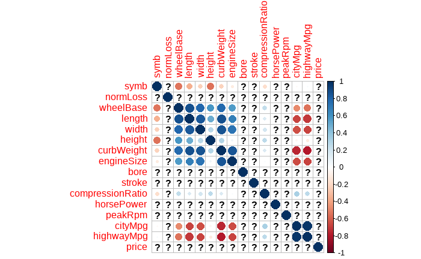

```r
library(corrplot)
numeric_data<- carIns[,sapply(carIns,is.numeric)]
cor_matrix<- cor(numeric_data)
corrplot(cor_matrix,method = "circle")
```